# Questionnaire Report for Swordfish

(MERA version 4.1.5)

Brett van Poorten (brett.vanpoorten@gmail.com)

2019-04-19

# 1 About this document

This is a prototype of an automatic report that documents how the user specified the operating model and their various justifications.

# 2 Introduction

1. Describe the history and current status of the fishery, including fleets, sectors, vessel types and practices/gear by vessel type, landing ports, economics/markets, whether targeted/bycatch, other stocks caught in the fishery.

“The Atlantic swordfish fishery began commercially in the late 1880s as harpoon sailing vessels fished swordfish throughout Atlantic Canada and eventually expanded their fishery along the annual migration patterns of the eastern seaboard of North America. In the early 1960s, the Atlantic swordfish fishery shifted from a harpoon to primarily a longline fishery and landings increased to a high of approximately 8,000t.” (http://www.dfo-mpo.gc.ca/fm-gp/peches-fisheries/ifmp-gmp/swordfish-espadon/NEW-swordfish-2013-espado-eng.htm)

“Due to the broad geographical distribution of Atlantic swordfish (SWO-ATL-Figure 1) in coastal and off- shore areas (mostly ranging from 50oN to 45oS), this species is available to a large number of fishing countries. SWO-ATL-Figure 2 shows total estimated catches for North and South Atlantic swordfish. Directed longline fisheries from Canada, EU-Spain, and the United States have operated since the late 1950s or early 1960s, and harpoon fisheries have existed at least since the late 1800s. Other directed swordfish fisheries include fleets from Brazil, Morocco, Namibia, EU-Portugal, South Africa, Uruguay, and Venezuela. The primary by-catch or opportunistic fisheries that take swordfish are tuna fleets from Chinese Taipei, Japan, Korea and EU-France. The tuna longline fishery started in 1956 and has operated throughout the Atlantic since then, with substantial catches of swordfish that are produced as a by-catch of tuna fisheries. The largest proportion of the Atlantic catches is made using surface-drifting longline. However, many additional gears are used, including traditional gillnets off the coast of western Africa.”; “For the past decade, the North Atlantic estimated catch (landings plus dead discards) has averaged about 12,000 t per year (SWO-ATL-Table 1). The catch in 2017 (10,046 t) represents a 50.4% decrease since the 1987 peak in North Atlantic landings (20,238 t). These reduced landings have been attributed to ICCAT regulatory recommendations and shifts in fleet distributions, including the movement of some vessels in certain years to the South Atlantic or out of the Atlantic. In addition, some fleets, including at least the United States, EU-Spain and EU-Portugal have changed operating procedures to opportunistically target tuna and/or sharks, taking advantage of market conditions and higher relative catch rates of these species previously considered as by-catch in some fleets. Recently, socio-economic factors may have also contributed to the decline in catch.” (https://www.iccat.int/Documents/SCRS/ExecSum/SWO_ATL_ENG.pdf).

2. Describe the stock’s ecosystem functions, dependencies, and habitat types.

“They range from Newfoundland and Labrador to Argentina in the western Atlantic, and from Norway to South Africa in the eastern Atlantic. They are also found in the Mediterranean Sea.” (http://www.dfo-mpo.gc.ca/species-especes/profiles-profils/swordfish-espadon-eng.html). They inhabit temperatures from 5-27C and can dive to depths of 200-600m.

3. Provide all relevant reference materials, such as assessments, research, and other analysis.

REPORT OF THE 2017 ICCAT ATLANTIC SWORDFISH STOCK ASSESSMENT SESSION: (https://www.iccat.int/Documents/Meetings/Docs/2017_ATL_SWO_ASS_REP_ENG.pdf)

SUMMARY REPORT: (https://www.iccat.int/Documents/SCRS/ExecSum/SWO_ATL_ENG.pdf)

# 3 Fishery Characteristics

## 3.1 Longevity

| Answered |
| --- |
| Very short-lived (5 < maximum age < 7) |
| Short-lived (7 < maximum age < 10) |
| Moderate life span (10 < maximum age < 20) |
| Moderately long-lived (20 < maximum age < 40) |
| Long-lived (40 < maximum age < 80) |
| Very long-lived (80 < maximum age < 160) |

| Justification |
| --- |
| “Tagging studies have shown that some swordfish can live up to 15 years.” (Summary Report) |

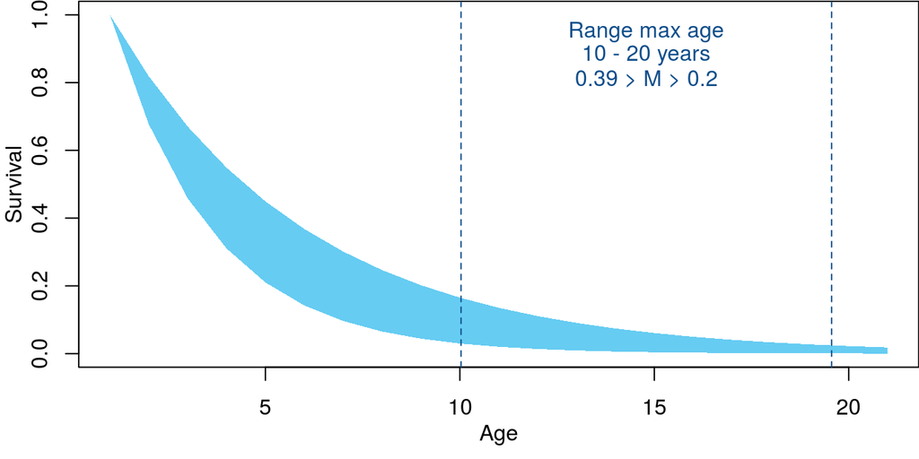

## 3.2 Stock depletion

| Answered |
| --- |
| Crashed (D < 0.05) |
| Very depleted (0.05 < D < 0.1) |
| Depleted (0.1 < D < 0.15) |
| Moderately depleted (0.15 < D < 0.3) |
| Healthy (0.3 < D < 0.5) |
| Underexploited (0.5 < D) |

[output not shown]

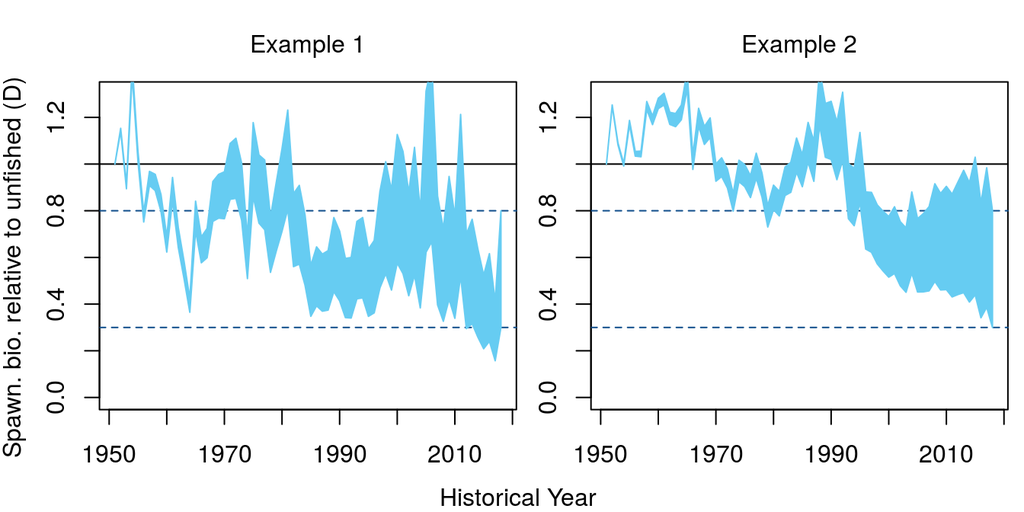

## 3.3 Resilence

| Answered |
| --- |
| Not resilient (steepness < 0.3) |
| Low resilience (0.3 < steepness < 0.5) |
| Moderate resilence (0.5 < steepness < 0.7) |
| Resilient (0.7 < steepness < 0.9) |
| Very Resilient (0.9 < steepness) |

[output not shown]

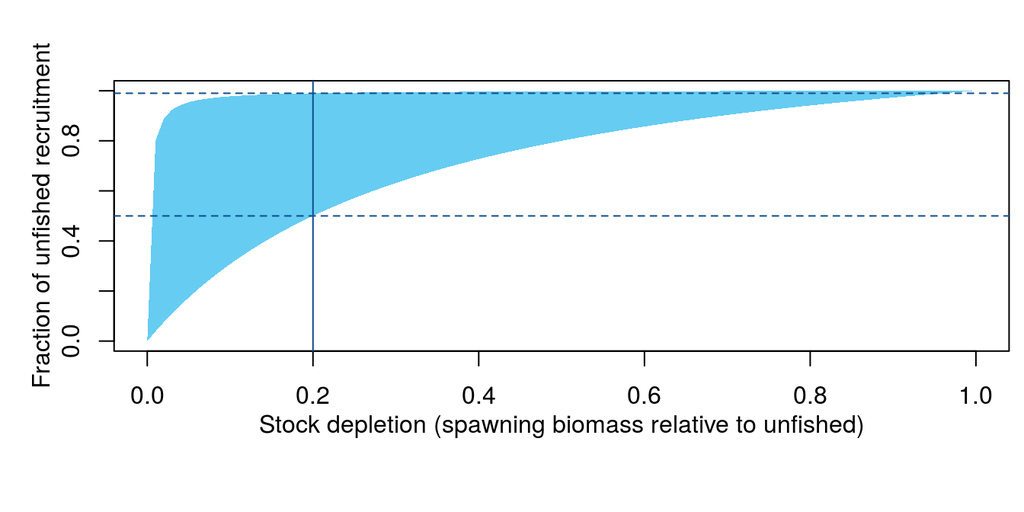

## 3.4 Historical effort pattern

| Answered |
| --- |
| Stable |
| Two-phase |
| Boom-bust |
| Gradual increases |
| Stable, recent increases |
| Stable, recent declines |

[output not shown]

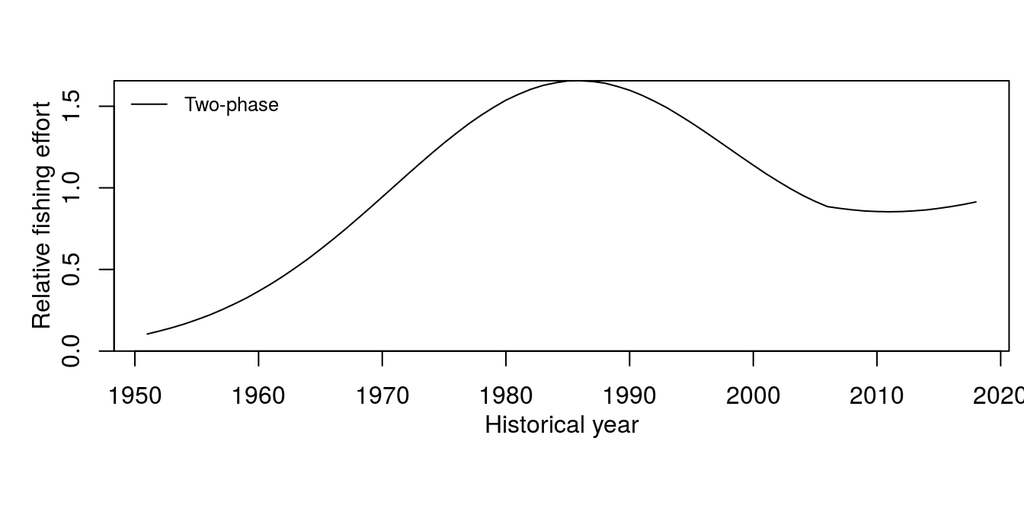

## 3.5 Inter-annual variability in historical effort

| Answered |
| --- |
| Not variable (less than 20% inter-annual change (IAC)) |
| Variable (maximum IAC between 20% to 50%) |
| Highly variable (maximum IAC between 50% and 100%) |

[output not shown]

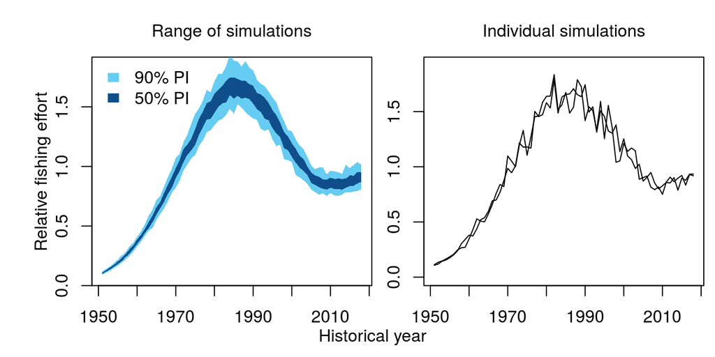

## 3.6 Historical fishing efficiency changes

| Answered |
| --- |
| Declining by 2-3% pa (halves every 25-35 years) |
| Declining by 1-2% pa (halves every 35-70 years) |
| Stable -1% to 1% pa (may halve/double every 70 years) |
| Increasing by 1-2% pa (doubles every 35-70 years) |
| Increasing by 2-3% pa (doubles every 25-35 years) |

| Justification |
| --- |
| This fishery is primarily longline, which has persisted relatively unchanged since the 1950s. Small increases in efficiency are likely due to increased communication and advances in technology. |

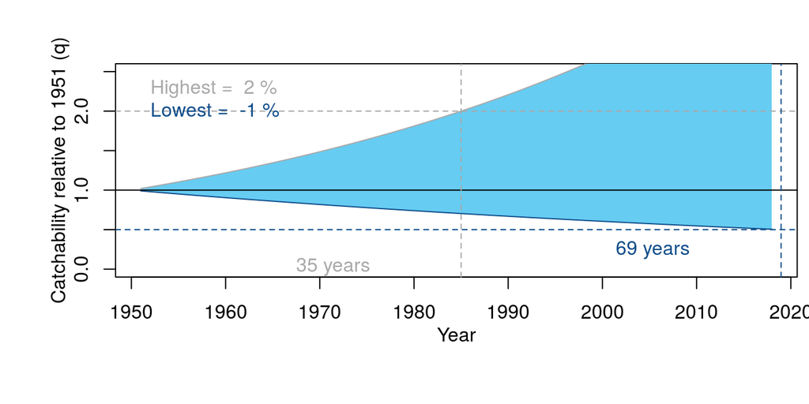

## 3.7 Future fishing efficiency changes

| Answered |
| --- |
| Declining by 2-3% pa (halves every 25-35 years) |
| Declining by 1-2% pa (halves every 35-70 years) |
| Stable -1% to 1% pa (may halve/double every 70 years) |
| Increasing by 1-2% pa (doubles every 35-70 years) |
| Increasing by 2-3% pa (doubles every 25-35 years) |

[output not shown]

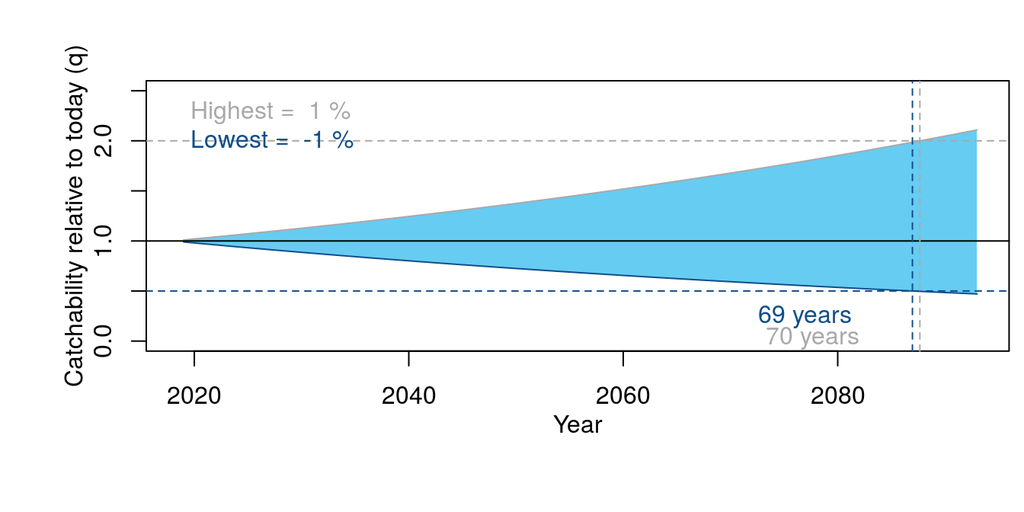

## 3.8 Length at maturity

| Answered |
| --- |
| Very small (0.4 < LM < 0.5) |
| Small (0.5 < LM < 0.6) |
| Moderate (0.6 < LM < 0.7) |
| Moderate to large (0.7 < LM < 0.8) |
| Large (0.8 < LM < 0.9) |

| Justification |
| --- |
| 50% of fish are considered mature at age-5 or 180 cm. Fish in the assessments have been observed up to ~250 cm |

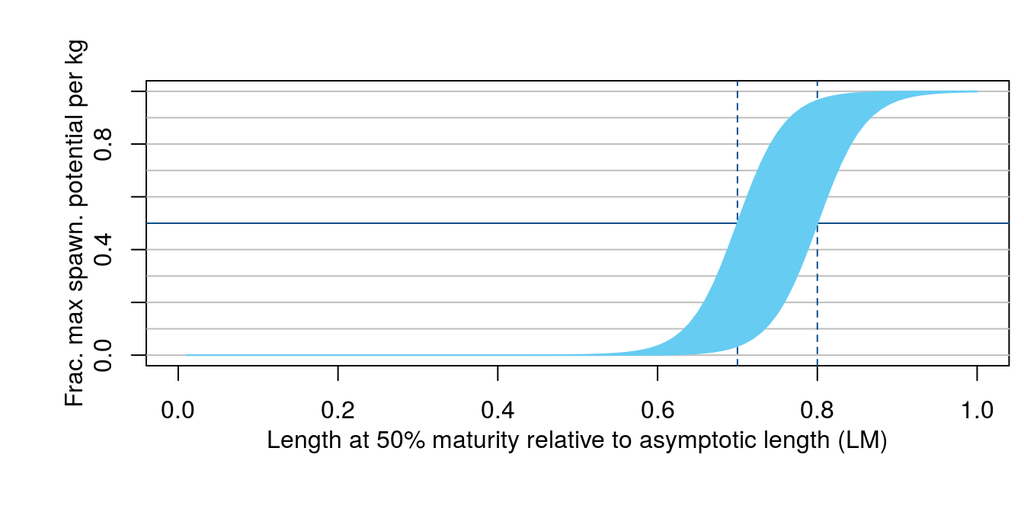

## 3.9 Selectivity of small fish

| Answered |
| --- |
| Very small (0.1 < S < 0.2) |
| Small (0.2 < S < 0.4) |
| Half asymptotic length (0.4 < S < 0.6) |
| Large (0.6 < S < 0.8) |
| Very large (0.8 < S < 0.9) |

| Justification |
| --- |
| Selectivity is age-based. Maximum selectivity for most fleets is reached before age-5, which is approximately 60% of Linf. (Figure saved - selectivity.png) |

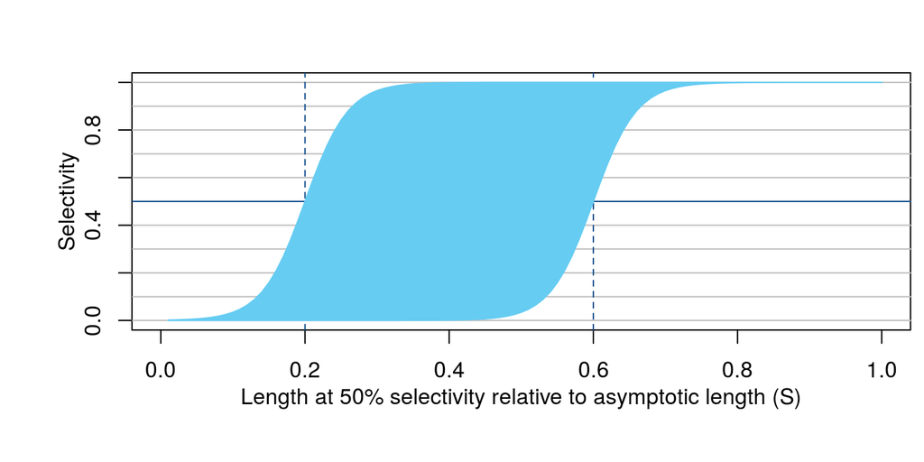

## 3.10 Selectivity of large fish

| Answered |
| --- |
| Asymptotic selectivity (SL = 1) |
| Declining selectivity with length (0.75 < SL < 1) |
| Dome-shaped selectivity (0.25 < SL < 0.75) |
| Strong dome-shaped selectivity (SL < 0.25) |

| Justification |
| --- |
| Decline in selectivity across fleets is quite variable with some countries asymptotic, others declining to low selectivity by age-5 (Figure Selectivity.png) |

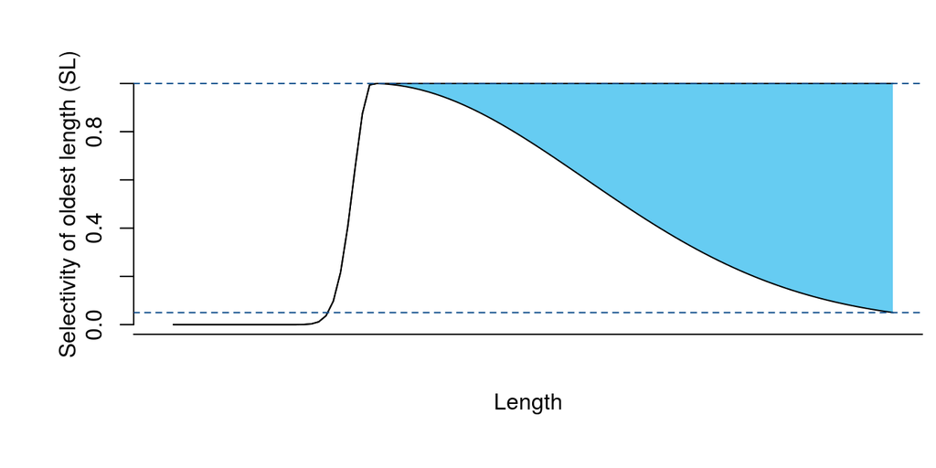

## 3.11 Discard rate

| Answered |
| --- |
| Low (DR < 1%) |
| Low - moderate (1% < DR < 10%) |
| Moderate (10% < DR < 30%) |
| Moderate - high (30% < DR < 50%) |
| High (50% < DR < 70%) |

[output not shown]

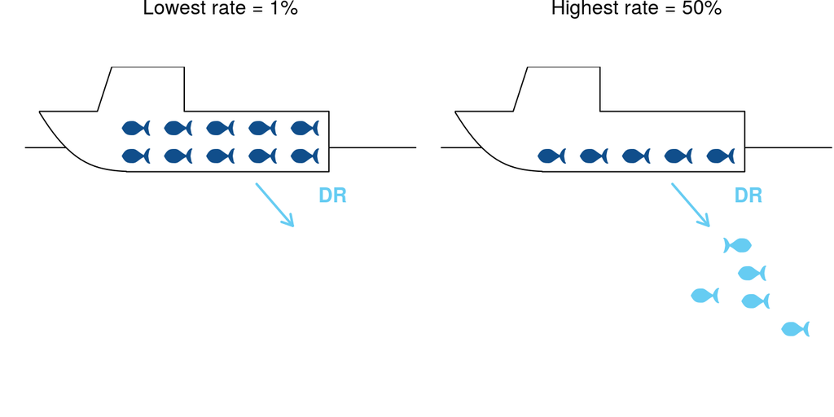

## 3.12 Post-release mortality rate

| Answered |
| --- |
| Low (PRM < 5%) |
| Low - moderate (5% < PRM < 25%) |
| Moderate (25% < PRM < 50%) |
| Moderate - high (50% < PRM < 75%) |
| High (75% < PRM < 95%) |
| Almost all die (95% < PRM < 100%) |

[output not shown]

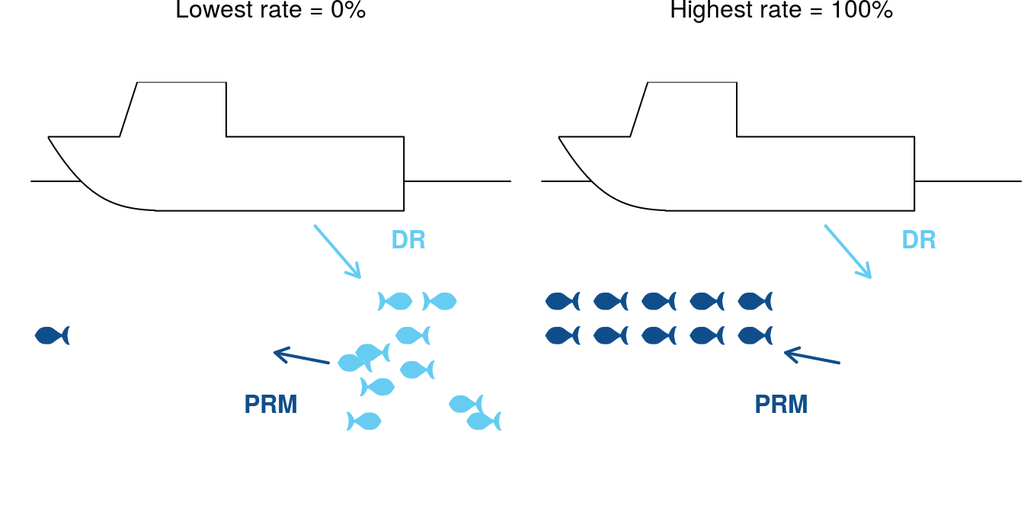

## 3.13 Recruitment variability

| Answered |
| --- |
| Very low (less than 10% inter-annual changes (IAC)) |
| Low (max IAC of between 20% and 60%) |
| Moderate (max IAC of between 60% and 120%) |
| High (max IAC of between 120% and 180%) |
| Very high (max IAC greater than 180%) |

| Justification |
| --- |
| Presumed recruitment SD of 0.6 in the stock assessment |

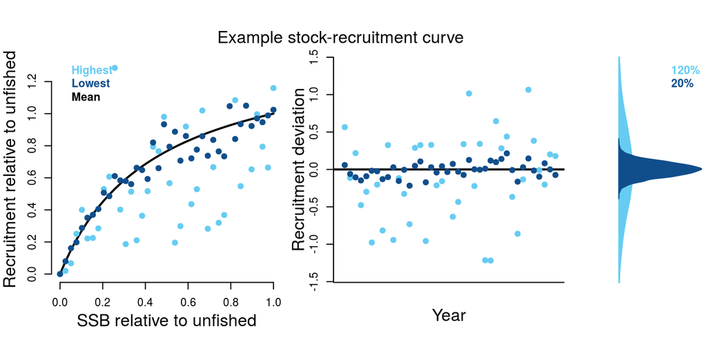

## 3.14 Size of an existing MPA

| Answered |
| --- |
| None |
| Small (A < 5%) |
| Small-moderate (5% < A < 10%) |
| Moderate (10% < A < 20%) |
| Large (20% < A < 30%) |
| Very large (30% < A < 40%) |
| Huge (40% < A < 50%) |

[output not shown]

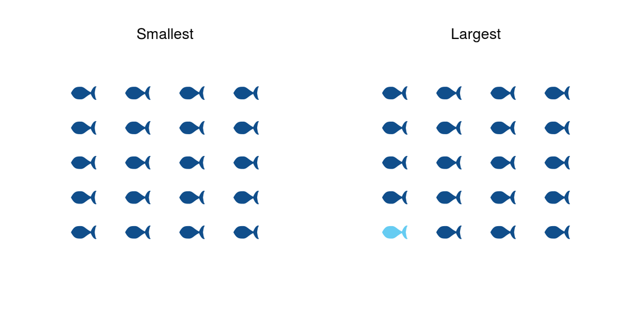

## 3.15 Spatial mixing (movement) in/out of existing MPA

| Answered |
| --- |
| Very low (P < 1%) |
| Low (1% < P < 5%) |
| Moderate (5% < P < 10%) |
| High (10% < P < 20%) |
| Fully mixed |

| Justification |
| --- |
| This is a highly migratory species; it is likely that closures do not limit fishing of vulnerable sizes. |

[figure not shown]

## 3.16 Size of a future potential MPA

| Answered |
| --- |
| None |
| Small (A < 5%) |
| Small-moderate (5% < A < 10%) |
| Moderate (10% < A < 20%) |
| Large (20% < A < 30%) |
| Very large (30% < A < 40%) |
| Huge (40% < A < 50%) |

| Justification |
| --- |
| No additional spatial closures are being considered |

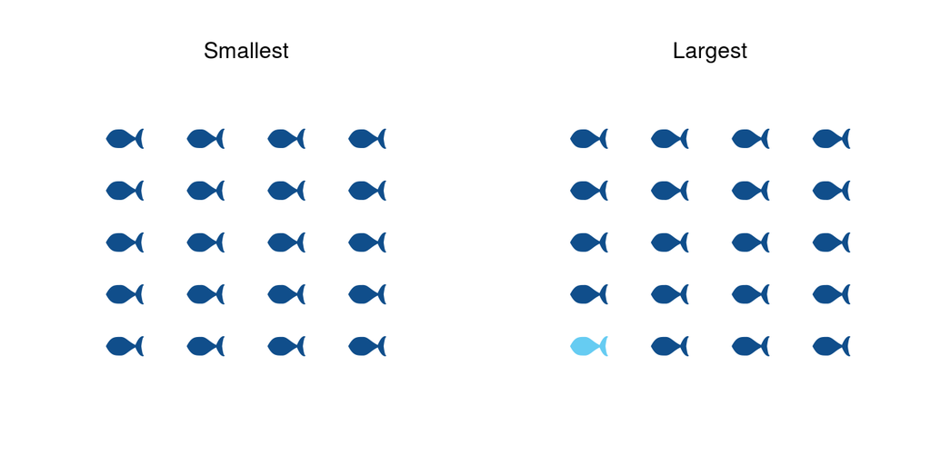

## 3.17 Spatial mixing (movement) in/out of future potential MPA

| Answered |
| --- |
| Very low (P < 1%) |
| Low (1% < P < 5%) |
| Moderate (5% < P < 10%) |
| High (10% < P < 20%) |
| Fully mixed |

| Justification |
| --- |
| This is a highly migratory species; spatial closures are unlikely to limit fishing mortality of vulnerable fish |

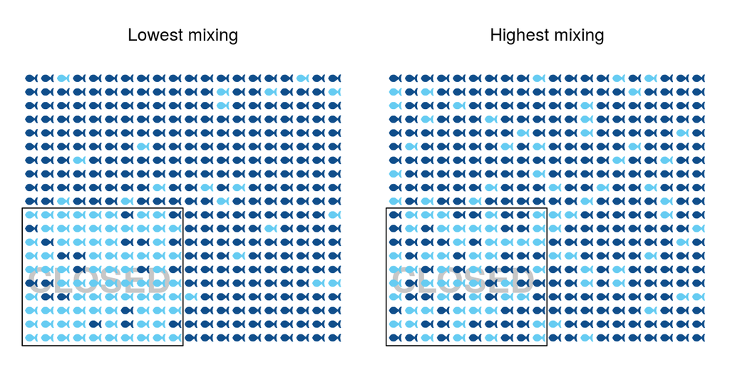

## 3.18 Initial stock depletion

| Answered |
| --- |
| Very low (0.1 < D1 < 0.15) |
| Low (0.15 < D1 < 0.3) |
| Moderate (0.3 < D < 0.5) |
| High (0.5 < D1) |
| Asymptotic unfished levels (D1 = 1) |

[output not shown]

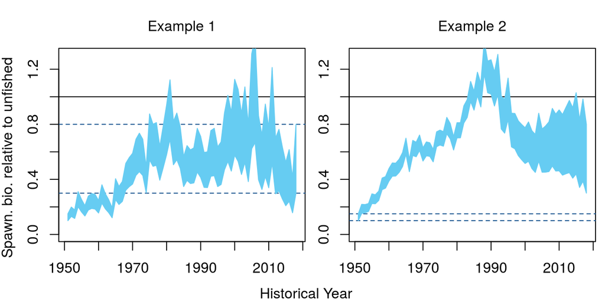

# 4 Management Characteristics

## 4.1 Types of fishery management that are possible

| Answered |
| --- |
| TAC (Total Allowable Catch): a catch limit |
| TAE (Total Allowable Effort): an effort limit |
| Size limit |
| Time-area closures (a marine reserve) |

[output not shown]

## 4.2 TAC offset: consistent overages/underages

| Answered |
| --- |
| Large underages (40% - 70% of recommended) |
| Underages (70% - 90% of recommended) |
| Slight underages (90% - 100% of recommended) |
| Taken exactly (95% - 105% of recommended) |
| Slight overages (100% - 110% of recommended) |
| Overages (110% - 150% of recommended) |
| Large overages (150% - 200% of recommended) |

| Justification |
| --- |
| Consistently take slightly less than quota (See Figure 2 Summary.png from the summary document). Overages that could occur are transferred to future years. |

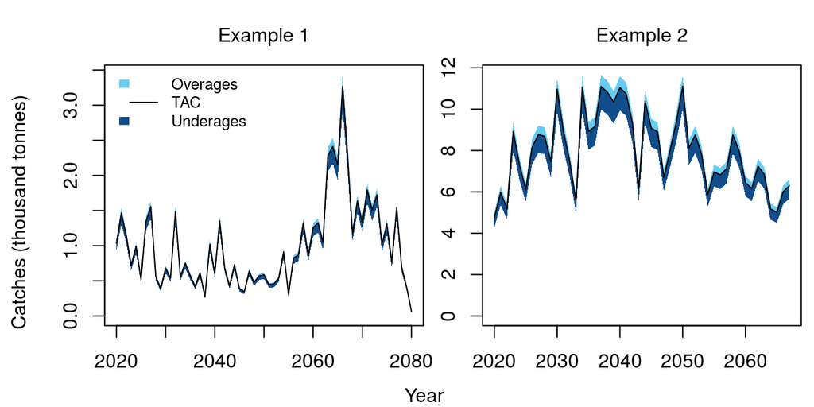

## 4.3 TAC implementation variability

| Answered |
| --- |
| Constant (V < 1%) |
| Not variable (1% < V < 5%) |
| Low variability (5% < V < 10%) |
| Variable (10% < V < 20%) |
| Highly variable (20% < V < 40%) |

| Justification |
| --- |
| TAC is quite consistent between years, especially in recent years since the stock is stable and healthy (See Figure 2 Summary.png) |

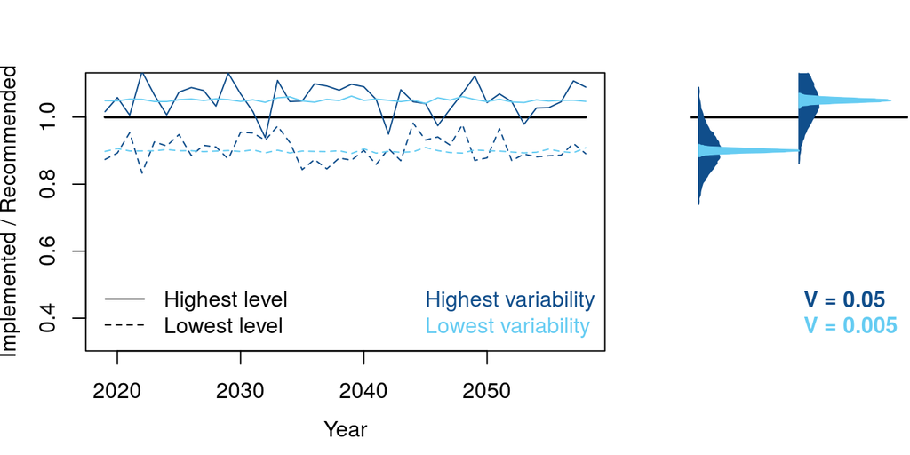

## 4.4 TAE offset: consistent overages/underages

| Answered |
| --- |
| Large underages (40% - 70% of recommended) |
| Underages (70% - 90% of recommended) |
| Slight underages (90% - 100% of recommended) |
| Taken exactly (95% - 105% of recommended) |
| Slight overages (100% - 110% of recommended) |
| Overages (110% - 150% of recommended) |
| Large overages (150% - 200% of recommended) |

| Justification |
| --- |
| No justification was provided |

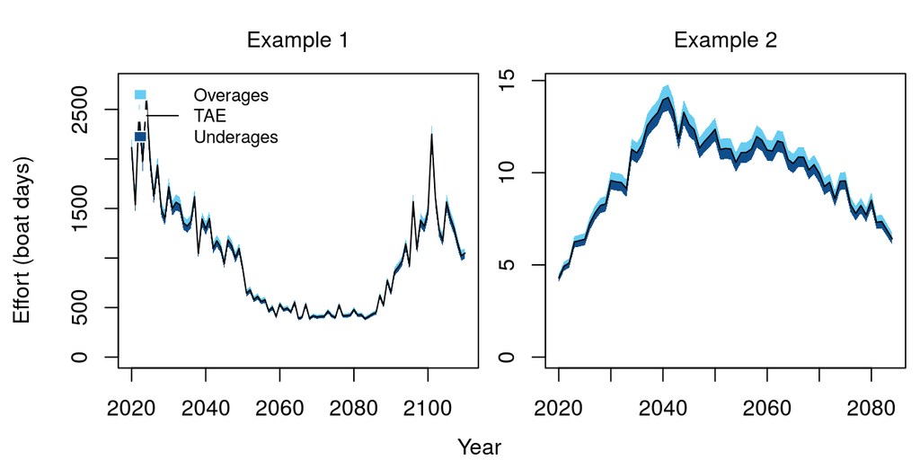

## 4.5 TAE implementation variability

| Answered |
| --- |
| Constant (V < 1%) |
| Not variable (1% < V < 5%) |
| Low variability (5% < V < 10%) |
| Variable (10% < V < 20%) |
| Highly variable (20% < V < 40%) |

| Justification |
| --- |
| TAE is not really implemented, beyond limiting the number of licenses and some trip limits (in Canada at least: Andrushchenko et al. 2014) |

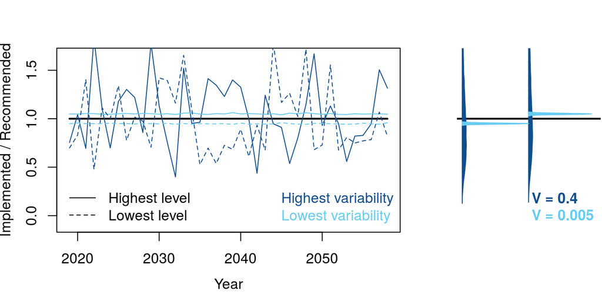

## 4.6 Size limit offset: consistent overages/underages

| Answered |
| --- |
| Much smaller (40% - 70% of recommended) |
| Smaller (70% - 90% of recommended) |
| Slightly smaller (90% - 100% of recommended) |
| Taken exactly (95% - 105% of recommended) |
| Slightly larger (100% - 110% of recommended) |
| Larger (110% - 150% of recommended) |
| Much larger (150% - 200% of recommended) |

| Justification |
| --- |
| Onboard observers and port observers appear to keep catch within size limits |

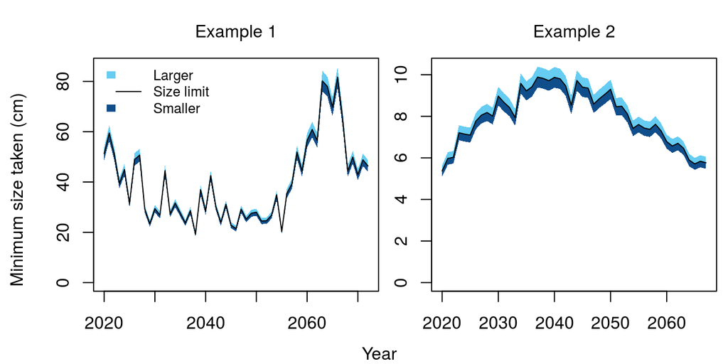

## 4.7 Size limit implementation variability

| Answered |
| --- |
| Constant (V < 1%) |
| Not variable (1% < V < 5%) |
| Low variability (5% < V < 10%) |
| Variable (10% < V < 20%) |
| Highly variable (20% < V < 40%) |

| Justification |
| --- |
| No indication that size limits have changed much over time. |

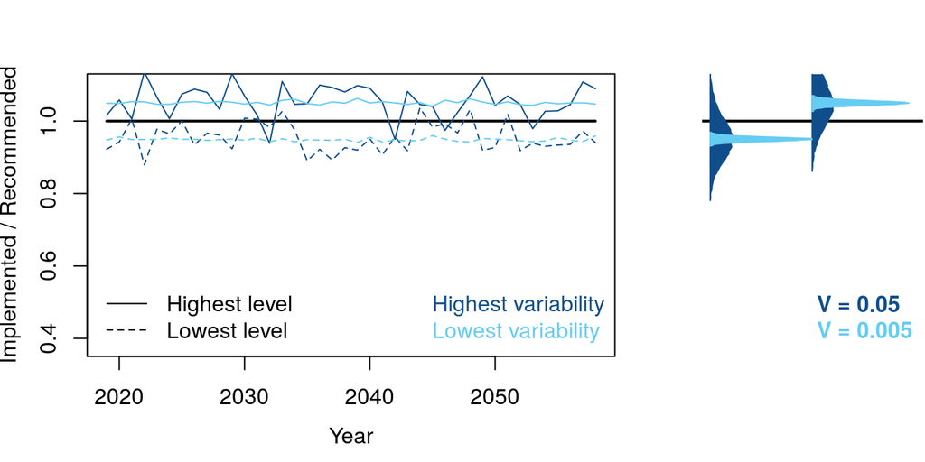

# 5 Data Characteristics

## 5.1 Available data types

| Answered |
| --- |
| Historical annual catches (from unfished) |
| Recent annual catches (at least 5 recent years) |
| Historical relative abundance index (from unfished) |
| Recent relative abundance index (at least 5 recent years) |
| Fishing effort |
| Size composition (length samples) |
| Age composition (age samples) |
| Growth (growth parameters) |
| Absolute biomass survey |

Justification

1. Provide the time series (specify years, if possible) that exist for catch, effort, and CPUE/abundance indices.  
Catches extend back to 1950, although harpoon fishery extends back to 1880s with no data.  
Standardized CPUE extends back for some countries as 1962.  
Size-at-age extends back to 1968  
Length composition exists, but seems to be aggregated over time.  
2. Describe how these data collected (e.g., log books, dealer reporting, observers).  
Data are collected through log book reporting and observers. Logbook reporting in Canada started in 1994 (Andrushchenko et al. 2014).  
“Responsibility for reporting lies with the member country, but in the developed fisheries the monitoring mechanisms include logbook reports, monitoring of dealers, at‐sea observers and dockside sampling of sizes. In the case of the United States, these are all done.” (20130307_FR_Revised_SWO350.pdf)  
3. Describe what types of sampling programs and methodologies exist for data collection, including the time-series of available sampling data and quality.  
unknown  
4. Describe all sources of uncertainty in the status, biology, life history and data sources of the fishery. Include links to documentation, reports.  
Biology is relatively well established. Aging is difficult (see Summary document), but tagging helps understand spatial distribution (which is still somewhat uncertain).

## 5.2 Catch reporting bias

| Answered |
| --- |
| Strong under-reporting (30% - 50%) |
| Under-reporting (10% - 30%) |
| Slight under-reporting (less than 10%) |
| Reported accurately (+/- 5%) |
| Slight over-reporting (less than 10%) |

| Justification |
| --- |
| could not find any estimates of reporting accuracy rates |

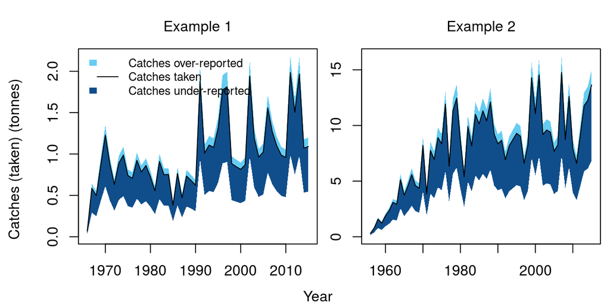

## 5.3 Hyperstability in indices

| Answered |
| --- |
| Strong hyperdepletion (2 < Beta < 3) |
| Hyperdepletion (1.25 < Beta < 2) |
| Proportional (0.8 < Beta < 1.25) |
| Hyperstability (0.5 < Beta < 0.8) |
| Strong hyperstability (0.33 < Beta < 0.5) |

[output not shown]

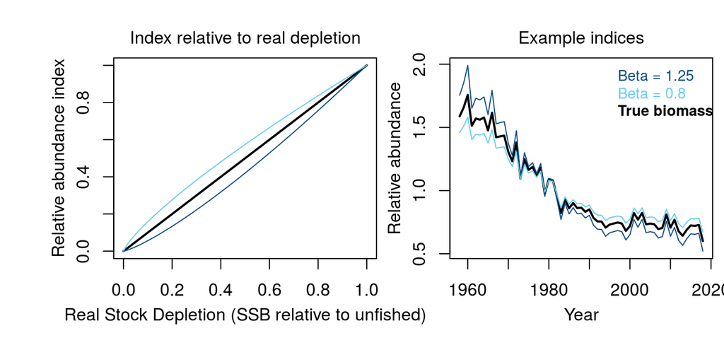

## 5.4 Available data types

| Answered |
| --- |
| Perfect |
| Good (accurate and precise) |
| Data moderate (some what inaccurate and imprecise) |
| Data poor (inaccurate and imprecise) |

| Justification |
| --- |
| Strict standards in many countries. high observer rates. Assumed good. |

# 6 Version Notes

The package is subject to ongoing testing. If you find a bug or a problem please send a report to t.carruthers@oceans.ubc.ca so that it can be fixed!

shiny-2019-04-19-23:11:17

copyright (c) NRDC 2019